# Area Deprivation Index for Pennsylvania 2020

BMIN503/EPID600 Final Project

Author

Dana Neugut

## 1 Overview

Social determinants of health have a notable impact on health outcomes. The Area Deprivation Index (ADI) is a composite measure of “deprivation,” based on census block data from 1969 through 1998, that can be used in health outcomes research. In this project, we update the ADI using more recent census data.

I met with Drs. Amanda Muir and Lindsey Albenberg to gain insight on which census variables may be helpful to include in initial analyses, and to discuss analytic approaches. This project can be found at this [link to GitHub repository](https://github.com/ydnuggs/BMIN503_Final_Project).

## 2 Introduction

In 2002, Gopal Singh published the Area Deprivation Index (ADI), a “composite area-based deprivation index for the United States” based on census data from 1969 to 1998. It has become a tool used to examine, on an area-based scale, how social determinants of health can have an impact on health outcomes. The Area Deprivation Index uses factor score coefficients based on census data. However, neighborhoods and their sociodemographic characteristics can change over time; therefore, it is important to re-examine these calculations intermittently. Furthermore, associations can differ by states, where there are different laws and demographic factors affecting access to resources. In this project, we use recent data from the 2020 U.S. decennial census and the 2016-2020 5-year American Community Survey (ACS) to reconstruct the ADI for Pennsylvania and re-calculate the factor score coefficients. We then test whether the ADI is associated with several health outcomes, using tract level data.

The ADI is useful for health disparities research, which is an important area in all fields of research. There are several other indices that measure socioeconomic status (SES) in some way; these include the Townsend Deprivation Index, Social Disadvantage Index, and others. The ADI is one of the oldest validated indices for SES, and therefore it is the one we use in this paper.

## 3 Methods

In order to calculate the ADI for Pennsylvania in 2020, we first analyze the 17 sociodemographic factors that Singh described in his paper. We import these from the 2020 U.S. Decennial Census Survey and 2016-2020 5-Year American Community Survey. We visualize each characteristic and log-transform those without a Normal distribution. We then use factor analysis to derive factor-score coefficients with which we can calculate the ADI for each tract.

We import health outcomes data from 2020 CDC PLACES, and use these to test whether the ADI is associated with health outcomes data. We chose five health outcomes to test: obesity because it is associated with many health outcomes; stroke and coronary heart disease because they can lead to significant morbidity and mortality; and disability and self-reported health rating because they can serve as quality of life metrics.

### 3.1 Loading packages

```r
# Load necessary packages
library(tidyverse)
library(gtsummary)
library(sf)
library(tidycensus)
library(ggspatial)
library(leaflet)
library(nhanesA)
library(gtsummary)
library(readxl)
library(ggbiplot)
library(psych)
library(knitr)
library(kableExtra)
library(gridExtra)
library(tigris)
options(tigris_use_cache = TRUE)
options(progress_enabled = FALSE)
```

```r
# Use a Census API Key to perform queries with tidycensus in R, to use data from the Decennial Census and the American Community Survey (ACS).
#| eval: FALSE
census_api_key("8d4ae400e665d714446a25ed86d77a9125c57ec6", install = TRUE, overwrite = TRUE)
```

```
Your original .Renviron will be backed up and stored in your R HOME directory if needed.
```

```
Your API key has been stored in your .Renviron and can be accessed by Sys.getenv("CENSUS_API_KEY").
To use now, restart R or run `readRenviron("~/.Renviron")`
```

```
[1] "8d4ae400e665d714446a25ed86d77a9125c57ec6"
```

### 3.2 Preparing the data: predictors, i.e. sociodemographic variables

These are the factors from Singh’s seminal paper, and their corresponding factor score coefficients, that we seek to replicate in 2020 Pennsylvania (as listed in PMID 12835199).

```r
# Create the data frame with the characteristics and corresponding factor score coefficients
data_singh <- data.frame(
  Characteristic = c(
    "Percent of the block group’s population aged ≥ 25 years with < 9 years of education",
    "Percent aged ≥ 25 years with greater than or equal to a high school diploma",
    "Percent of employed persons ≥16 years of age in white-collar occupations",
    "Median family income",
    "Income disparity",
    "Median home value",
    "Median gross rent",
    "Median monthly mortgage",
    "Percent owner-occupied housing units (home ownership rate)",
    "Percent of civilian labor force population ≥ 16 years of age unemployed (unemployment rate)",
    "Percent of families below the poverty level",
    "Percent of population below 150% of the poverty threshold",
    "Percent of single-parent households with children < 18 years of age",
    "Percent of occupied housing units without a motor vehicle",
    "Percent of occupied housing units without a telephone",
    "Percent of occupied housing units without complete plumbing (log)",
    "Percent of occupied housing units with more than one person per room (crowding)"
  ),
  Factor_Score_Coefficient = c(
    0.0849, -0.0970, -0.0874, -0.0977, 0.0936, -0.0688, -0.0781,
    -0.0770, -0.0615, 0.0806, 0.0977, 0.1037, 0.0719, 0.0694,
    0.0877, 0.0510, 0.0556
  )
)

# View the table
data_singh |>
  kable(format = "html", col.names = c("Census Block Characteristics", "Factor Score Coefficients")) |>
  kable_styling(
    bootstrap_options = c("striped", "hover", "condensed"),
    full_width = FALSE,
    position = "center"
  ) |>
  column_spec(1, width = "20em") |>
  column_spec(2, width = "10em")
```

| Census Block Characteristics | Factor Score Coefficients |
| --- | --- |
| Percent of the block group’s population aged ≥ 25 years with < 9 years of education | 0.0849 |
| Percent aged ≥ 25 years with greater than or equal to a high school diploma | -0.0970 |
| Percent of employed persons ≥16 years of age in white-collar occupations | -0.0874 |
| Median family income | -0.0977 |
| Income disparity | 0.0936 |
| Median home value | -0.0688 |
| Median gross rent | -0.0781 |
| Median monthly mortgage | -0.0770 |
| Percent owner-occupied housing units (home ownership rate) | -0.0615 |
| Percent of civilian labor force population ≥ 16 years of age unemployed (unemployment rate) | 0.0806 |
| Percent of families below the poverty level | 0.0977 |
| Percent of population below 150% of the poverty threshold | 0.1037 |
| Percent of single-parent households with children < 18 years of age | 0.0719 |
| Percent of occupied housing units without a motor vehicle | 0.0694 |
| Percent of occupied housing units without a telephone | 0.0877 |
| Percent of occupied housing units without complete plumbing (log) | 0.0510 |
| Percent of occupied housing units with more than one person per room (crowding) | 0.0556 |

We create a dataset with the 2020 Decennial Census variables from the Demographic and Housing Characteristics (DHC) dataset. We do the same for the 2016-2020 ACS 5-year Variables. These datasets can be used to identify the variables of interest based on their decriptions in the files.

```r
# 2020 Decennial Census variables with Demographic and Housing Characteristics
decennial_2020_vars_dhc <- load_variables(
                              year = 2020,
                              "dhc", #decennial census Demographic and Housing Characteristics file
                              cache = TRUE
                             )

# 2016-2020 ACS 5-year Variables
acs_2020_vars <- load_variables(
  year = 2020,
  "acs5",
  cache = TRUE
)
```

We then create datasets with each variable/s of interest. The survey datasets contain data counts and the total count surveyed, per geographic area. Therefore, we also calculate a frequency, which is the count divided by the total count, for each variable. Some variables contain sub-categories that are not of particular interest to us, so in these cases we combine multiple sub-categories to obtain the broader categories in which we are interested (for example, we combine the frequency of male single parents and of female single parents within the population, to obtain a total frequency of single parents).

```r
## educational attainment
vars_acs_education = c(
        #all = "B17003_001", #2020 Population 25+ for whom Poverty Status is Determined (ACS 5-Yr)
        pov_below_m_lesshighschool = "B17003_004", #2020 Male 25+ Below Poverty: < High School Grad (ACS 5-Yr)
        pov_below_m_highschoolgrad = "B17003_005", #2020 Male 25+ Below Poverty: High School Grad (ACS 5-Yr)
        pov_below_m_associates = "B17003_006", #2020 Male 25+ Below Poverty: Some college, associate's degree (ACS 5-Yr)
        pov_below_m_collegegrad = "B17003_007", #2020 Male 25+ Below Poverty: Bachelor/Higher (ACS 5-Yr)
        pov_below_f_lesshighschool = "B17003_009", #2020 Female 25+ Below Poverty: < High School Grad (ACS 5-Yr)
        pov_below_f_highschoolgrad = "B17003_010", #2020 Female 25+ Below Poverty: High School Grad (ACS 5-Yr)
        pov_below_f_associates = "B17003_011", #2020 Female 25+ Below Poverty: Some college, associate's degree (ACS 5-Yr)
        pov_below_f_collegegrad = "B17003_012", #2020 Female 25+ Below Poverty: Bachelor/Higher (ACS 5-Yr)
        pov_above_m_lesshighschool = "B17003_015", #2020 Male 25+ Above Poverty: < High School Grad (ACS 5-Yr)
        pov_above_m_highschoolgrad = "B17003_016", #2020 Male 25+ Above Poverty: High School Grad (ACS 5-Yr)
        pov_above_m_associates = "B17003_017", #2020 Male 25+ Above Poverty: Some college, associate's degree (ACS 5-Yr)
        pov_above_m_collegegrad = "B17003_018", #2020 Male 25+ Above Poverty: Bachelor/Higher (ACS 5-Yr)
        pov_above_f_lesshighschool = "B17003_020", #2020 Female 25+ Above Poverty: < High School Grad (ACS 5-Yr)
        pov_above_f_highschoolgrad = "B17003_021", #2020 Female 25+ Above Poverty: High School Grad (ACS 5-Yr)
        pov_above_f_associates = "B17003_022", #2020 Female 25+ Above Poverty: Some college, associate's degree (ACS 5-Yr)
        pov_above_f_collegegrad = "B17003_023" #2020 Female 25+ Above Poverty: Bachelor/Higher (ACS 5-Yr)
        )

data_acs_education = get_acs(
  geography = "tract",
  state = "PA",
  variables = vars_acs_education,
  summary_var = "B17003_001", #creates a column w/'total' variable
  year = 2020
)
# Summarize the data
data_acs_education <- data_acs_education |>
  mutate(category = case_when(
    variable %in% c("pov_below_m_lesshighschool", "pov_below_f_lesshighschool", "pov_above_m_lesshighschool", "pov_above_f_lesshighschool") ~ "lesshighschool",
    variable %in% c("pov_below_m_highschoolgrad", "pov_below_f_highschoolgrad", "pov_above_m_highschoolgrad", "pov_above_f_highschoolgrad") ~ "highschoolgrad",
    variable %in% c("pov_below_m_associates", "pov_below_f_associates", "pov_above_m_associates", "pov_above_f_associates") ~ "associates",
    variable %in% c("pov_below_m_collegegrad", "pov_below_f_collegegrad", "pov_above_m_collegegrad", "pov_above_f_collegegrad") ~ "collegegrad",
    TRUE ~ NA_character_  # Handle cases that do not fall into these categories
  ))

data_acs_education <- data_acs_education |>
  group_by(GEOID, category) |>
  summarise(
    estimate = sum(estimate, na.rm = TRUE),
    summary_est = first(summary_est),  # Assuming summary_est is the same for each group
    var_freq_education = estimate / summary_est,
    .groups = 'drop'
  )
rm(vars_acs_education)


## Population aged ≥ 25 y who did not graduate high school
# The earlier studies did <9 years of education
data_acs_less_highschool <- data_acs_education |> filter(category == "lesshighschool")
data_acs_less_highschool <- data_acs_less_highschool |>
  rename(var_freq_lesshighschool = var_freq_education)


## Population aged ≥ 25 y with at least an associates degree
# The earlier studies used at least a high school diploma
data_acs_associates_college <- data_acs_education |>
  filter(category %in% c("associates", "collegegrad")) |>
  group_by(GEOID) |>
  summarise(var_freq_associates_college = sum(var_freq_education, na.rm = TRUE))

rm(data_acs_education)

## White collar jobs: Employed persons aged ≥ 16 y in white-collar occupations, defined by "management, business, science, and arts occupations" and "sales and office occupations"
vars_acs_whitecollar = c(
        #all = "C24010_001", #total included in sex by occupation for the civilian employed population 16+ years of age
        management_m = "C24010_003", #Male: Management, business, science, and arts occupations
        sales_m = "C24010_027", #Male: Sales and office occupations
        management_f = "C24010_039", #Female: Management, business, science, and arts occupations
        sales_f = "C24010_063" #Female: Sales and office occupations
        )

data_acs_whitecollar = get_acs(
  geography = "tract",
  state = "PA",
  variables = vars_acs_whitecollar,
  summary_var = "C24010_001", #creates a column w/'total' variable
  year = 2020
)
data_acs_whitecollar <- data_acs_whitecollar |>
  group_by(GEOID) |>
  summarise(
    estimate = sum(estimate, na.rm = TRUE),
    summary_est = first(summary_est),  # Assuming summary_est is the same for each group
    var_freq_whitecollar = estimate / summary_est,
    .groups = 'drop'
  )
rm(vars_acs_whitecollar)


## median income
vars_acs_median_income = c(
        income_median = "B19326_001"
        )

data_acs_median_income = get_acs(
  geography = "tract",
  state = "PA",
  variables = vars_acs_median_income,
  year = 2020
)
data_acs_median_income <- data_acs_median_income |>
  rename(var_median_income = estimate)
rm(vars_acs_median_income)


## Income disparity
# Income disparity in 1990 was defined as the log of 100 × ratio of number of households with < $10 000 income to number of households with ≥$50 000 income.
# Instead we will use the Gini coefficient.
vars_acs_gini = c(
        gini = "B19083_001" #Gini Index of income inequality (higher indicates more inequality)
        )

data_acs_gini = get_acs(
  geography = "tract",
  state = "PA",
  variables = vars_acs_gini,
  year = 2020
)
data_acs_gini <- data_acs_gini |>
  rename(var_gini = estimate)
rm(vars_acs_gini)


## Median home value
vars_acs_home_value = c(
        home_value = "B25097_001" #median home value
        )

data_acs_home_value = get_acs(
  geography = "tract",
  state = "PA",
  variables = vars_acs_home_value,
  year = 2020
)
data_acs_home_value <- data_acs_home_value |>
  rename(var_home_value = estimate)
rm(vars_acs_home_value)


## Median gross rent
vars_acs_median_rent = c(
        median_rent = "B25064_001" #median gross rent (dollars)
        )

data_acs_median_rent = get_acs(
  geography = "tract",
  state = "PA",
  variables = vars_acs_median_rent,
  year = 2020
)
data_acs_median_rent <- data_acs_median_rent |>
  rename(var_median_rent = estimate)
rm(vars_acs_median_rent)


## Median monthly mortgage
# The monthly mortgage alone is not available. Instead we will use the "selected monthly owner costs." We will include units with and without mortgages (although there is data avilable if we wanted to separate by mortgage status).
vars_acs_housing_costs = c(
        housing_costs = "B25087_001" #selected monthly owner costs
        )

data_acs_housing_costs = get_acs(
  geography = "tract",
  state = "PA",
  variables = vars_acs_housing_costs,
  year = 2020
)
data_acs_housing_costs <- data_acs_housing_costs |>
  rename(var_housing_costs = estimate)
rm(vars_acs_housing_costs)


## owner-occupied housing units (home ownership rate)
vars_dhc_homeownership = c(
        #all = "H13_001N",
        owner_occupied = "H13_002N"
        )

data_dhc_homeownership = get_decennial(
  geography = "tract",
  state = "PA",
  variables = vars_dhc_homeownership,
  summary_var = "H13_001N", #creates a column w/'total' variable
  year = 2020,
  sumfile = "dhc"
)
```

```
Using the Demographic and Housing Characteristics File
```

```
Note: 2020 decennial Census data use differential privacy, a technique that
introduces errors into data to preserve respondent confidentiality.
ℹ Small counts should be interpreted with caution.
ℹ See https://www.census.gov/library/fact-sheets/2021/protecting-the-confidentiality-of-the-2020-census-redistricting-data.html for additional guidance.
```

```r
data_dhc_homeownership <- data_dhc_homeownership |>
  mutate(var_freq_homeownership = ifelse(summary_value != 0, value / summary_value, NA))
rm(vars_dhc_homeownership)


## Unemployment rate
vars_acs_unemployment = c(
        #all = "C18120_002", #in the labor force
        unemployment = "C18120_006" #unemployed in the labor force
        )

data_acs_unemployment = get_acs(
  geography = "tract",
  state = "PA",
  variables = vars_acs_unemployment,
  summary_var = "C18120_002", #creates a column w/'total' variable
  year = 2020
)
data_acs_unemployment <- data_acs_unemployment |>
  mutate(var_freq_unemployment = ifelse(summary_est != 0, estimate / summary_est, NA))
rm(vars_acs_unemployment)


## below poverty level
vars_acs_poverty = c(
        #all = "B06012_001",
        pov_level_below100 = "B06012_002", #Below 100 percent of the poverty level
        pov_level_100to149 = "B06012_003" #100 to 149 percent of the poverty level
        )

data_acs_poverty = get_acs(
  geography = "tract",
  state = "PA",
  variables = vars_acs_poverty,
  summary_var = "B06012_001", #creates a column w/'total' variable
  year = 2020
)
data_acs_poverty <- data_acs_poverty |>
  mutate(var_freq_poverty = ifelse(summary_est != 0, estimate / summary_est, NA))

data_acs_poverty_level <- data_acs_poverty |>
  filter(variable %in% "pov_level_below100")
data_acs_poverty_level <- data_acs_poverty_level |>
  rename(var_freq_poverty_level = var_freq_poverty)

rm(vars_acs_poverty)


## Population below 150% of the poverty threshold
# Combine the categories of below 100% of the poverty threshold + 100-149% of the poverty threshold, in order to obtain a composite number of the population below 150% of the poverty threshold
data_acs_poverty_level_150 <- data_acs_poverty |>
  mutate(category = case_when(
    variable %in% c("pov_level_below100", "pov_level_100to149") ~ "pov_level_below150",
    TRUE ~ NA_character_  # Handle cases that do not fall into these categories
  ))

data_acs_poverty_level_150 <- data_acs_poverty_level_150 |>
  group_by(GEOID, category) |>
  summarise(
    estimate = sum(estimate, na.rm = TRUE),
    summary_est = first(summary_est),  # Assuming summary_est is the same for each group
    var_freq_poverty_level_150 = estimate / summary_est,
    .groups = 'drop'
  )
rm(data_acs_poverty)


## Single-parent households with children aged < 18 y
vars_dhc_singleparent = c(
       #all = "P20_001N",
        singleparent_m = "P20_011N", #Male householder, no spouse or partner present, with own children under 18
        singleparent_f = "P20_017N" #Female householder, no spouse or partner present, with own children under 18
        )

data_dhc_singleparent = get_decennial(
  geography = "tract",
  state = "PA",
  variables = vars_dhc_singleparent,
  summary_var = "P20_001N", #creates a column w/'total' variable
  year = 2020,
  sumfile = "dhc"
)
```

```
Using the Demographic and Housing Characteristics File
```

```r
# Summarize the data
data_dhc_singleparent <- data_dhc_singleparent |>
  mutate(category = case_when(
    variable %in% c("singleparent_m", "singleparent_f") ~ "singleparent",
    TRUE ~ NA_character_  # Handle cases that do not fall into these categories
  ))

data_dhc_singleparent <- data_dhc_singleparent |>
  group_by(GEOID, category) |>
  summarise(
    value = sum(value, na.rm = TRUE),
    summary_value = first(summary_value),  # Assuming summary_est is the same for each group
    var_freq_singleparent = value / summary_value,
    .groups = 'drop'
  )
rm(vars_dhc_singleparent)


## no motor vehicle
vars_acs_novehicle = c(
        #all = "B08014_001", #2020 Workers Age 16+ in Households (ACS 5-Yr
        novehicle = "B08014_002" #No vehicle available
        )

data_acs_novehicle = get_acs(
  geography = "tract",
  state = "PA",
  variables = vars_acs_novehicle,
  summary_var = "B08014_001", #creates a column w/'total' variable
  year = 2020
)
data_acs_novehicle <- data_acs_novehicle |>
  mutate(var_freq_novehicle = ifelse(summary_est != 0, estimate / summary_est, NA))
rm(vars_acs_novehicle)


## Households without a telephone
#Are these correct? Seems like a high percentage...
vars_acs_no_telephone = c(
        #all = "B25043_001",
        no_telephone_owner = "B25043_007", #Owner occupied, no telephone service available
        no_telephone_renter = "B25043_016" #Renter occupied, no telephone service available
        )

data_acs_no_telephone = get_acs(
  geography = "tract",
  state = "PA",
  variables = vars_acs_no_telephone,
  summary_var = "B25043_001", #creates a column w/'total' variable
  year = 2020
)
# Summarize the data
data_acs_no_telephone <- data_acs_no_telephone |>
  mutate(category = case_when(
    variable %in% c("no_telephone_owner", "no_telephone_renter") ~ "no_telephone",
    TRUE ~ NA_character_  # Handle cases that do not fall into these categories
  ))

data_acs_no_telephone <- data_acs_no_telephone |>
  group_by(GEOID, category) |>
  summarise(
    estimate = sum(estimate, na.rm = TRUE),
    summary_est = first(summary_est),  # Assuming summary_est is the same for each group
    var_freq_no_telephone = estimate / summary_est,
    .groups = 'drop'
  )
rm(vars_acs_no_telephone)


## Occupied housing units without complete plumbing, % (log)
vars_acs_incomplete_plumbing = c(
        #all = "B25048_001", #plumbing facilities for occupied housing units
        incomplete_plumbing = "B25048_003" #Lacking complete plumbing facilities, for occupied housing units
        )

data_acs_incomplete_plumbing = get_acs(
  geography = "tract",
  state = "PA",
  variables = vars_acs_incomplete_plumbing,
  summary_var = "B25048_001", #creates a column w/'total' variable
  year = 2020
)
data_acs_incomplete_plumbing <- data_acs_incomplete_plumbing |>
  mutate(var_freq_incomplete_plumbing = ifelse(summary_est != 0, estimate / summary_est, NA))
rm(vars_acs_incomplete_plumbing)


## Households with more than 1 person per room, % (crowding)
vars_acs_overcrowding = c(
        #all = "B25014_001",
        occupance_1.01to1.50_owner = "B25014_005", #Owner occupied, 1.01 to 1.50 occupants per room
        occupance_1.51to2.00_owner = "B25014_006", #Owner occupied, 1.51 to 2.00 occupants per room
        occupance_2.01andup_owner = "B25014_007", #Owner occupied, 2.01 or more occupants per room
        occupance_1.01to1.50_renter = "B25014_011", #Renter occupied, 1.01 to 1.50 occupants per room
        occupance_1.51to2.00_renter = "B25014_012", #Renter occupied, 1.51 to 2.00 occupants per room
        occupance_2.01andup_renter = "B25014_013" #Renter occupied, 2.01 or more occupants per room
        )

data_acs_overcrowding = get_acs(
  geography = "tract",
  state = "PA",
  variables = vars_acs_overcrowding,
  summary_var = "B25014_001", #creates a column w/'total' variable
  year = 2020
)
# Summarize the data
data_acs_overcrowding <- data_acs_overcrowding |>
  mutate(category = case_when(
    variable %in% c("occupance_1.01to1.50_owner", "occupance_1.51to2.00_owner", "occupance_2.01andup_owner", "occupance_1.01to1.50_renter", "occupance_1.51to2.00_renter","occupance_2.01andup_renter") ~ "overcrowding",
    TRUE ~ NA_character_  # Handle cases that do not fall into these categories
  ))

data_acs_overcrowding <- data_acs_overcrowding |>
  group_by(GEOID, category) |>
  summarise(
    estimate = sum(estimate, na.rm = TRUE),
    summary_est = first(summary_est),  # Assuming summary_est is the same for each group
    var_freq_overcrowding = estimate / summary_est,
    .groups = 'drop'
  )
rm(vars_acs_overcrowding)
```

Extract the variable frequencies, and merge datasets to create one dataset with the 17 variables used in the ADI.

```r
## Combine variables

datasets <- list(data_acs_less_highschool, data_acs_associates_college, data_acs_incomplete_plumbing, data_acs_no_telephone, data_acs_novehicle, data_acs_overcrowding, data_acs_poverty_level, data_acs_poverty_level_150, data_acs_unemployment, data_acs_whitecollar, data_dhc_homeownership, data_dhc_singleparent, data_acs_median_income, data_acs_median_rent, data_acs_gini, data_acs_home_value, data_acs_housing_costs)

selected_datasets <- lapply(datasets, function(df) {
  df |>
    select(GEOID, starts_with("var_"))
})

# Merge all datasets by GEOID
merged_data <- selected_datasets[[1]]  # Start with the first dataset

for (i in 2:length(selected_datasets)) {
  merged_data <- full_join(merged_data, selected_datasets[[i]], by = "GEOID")
}
```

Next we visualize the demographic variables. For the variables without a Normal distribution, we log transform them to see if that achieves Normalization.

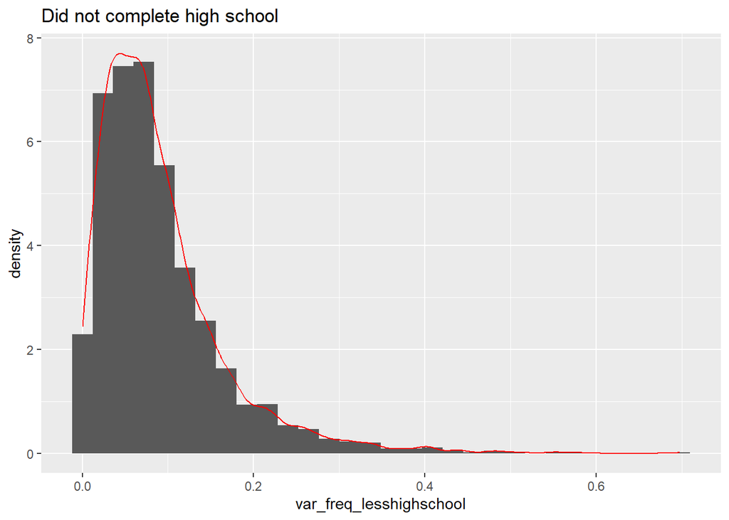

```r
# Histograms of the data to visualize the data distributions

ggplot(data = data_acs_less_highschool, aes(var_freq_lesshighschool)) +
  geom_histogram(aes(y = after_stat(density))) +
  geom_density(color = "red") +
    ggtitle("Did not complete high school")
```

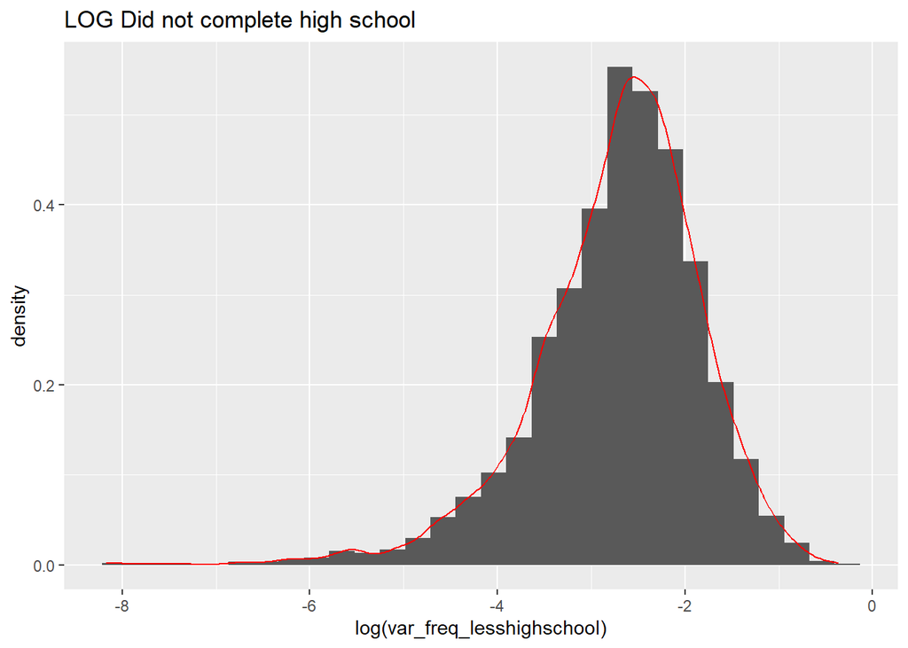

```r
ggplot(data = data_acs_less_highschool, aes(log(var_freq_lesshighschool))) +
  geom_histogram(aes(y = after_stat(density))) +
  geom_density(color = "red") +
    ggtitle("LOG Did not complete high school")
```

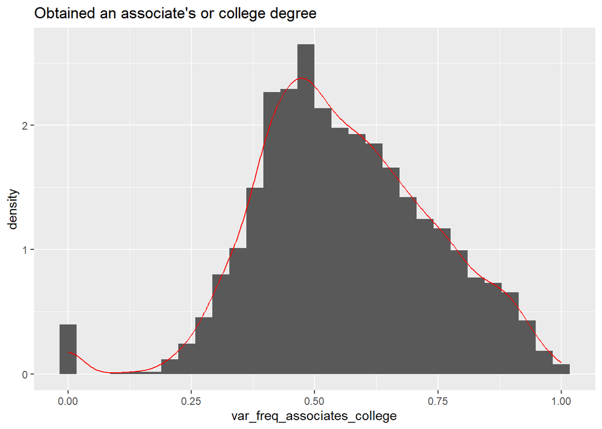

```r
ggplot(data = data_acs_associates_college, aes(var_freq_associates_college)) +
  geom_histogram(aes(y = after_stat(density))) +
  geom_density(color = "red") +
  ggtitle("Obtained an associate's or college degree")
```

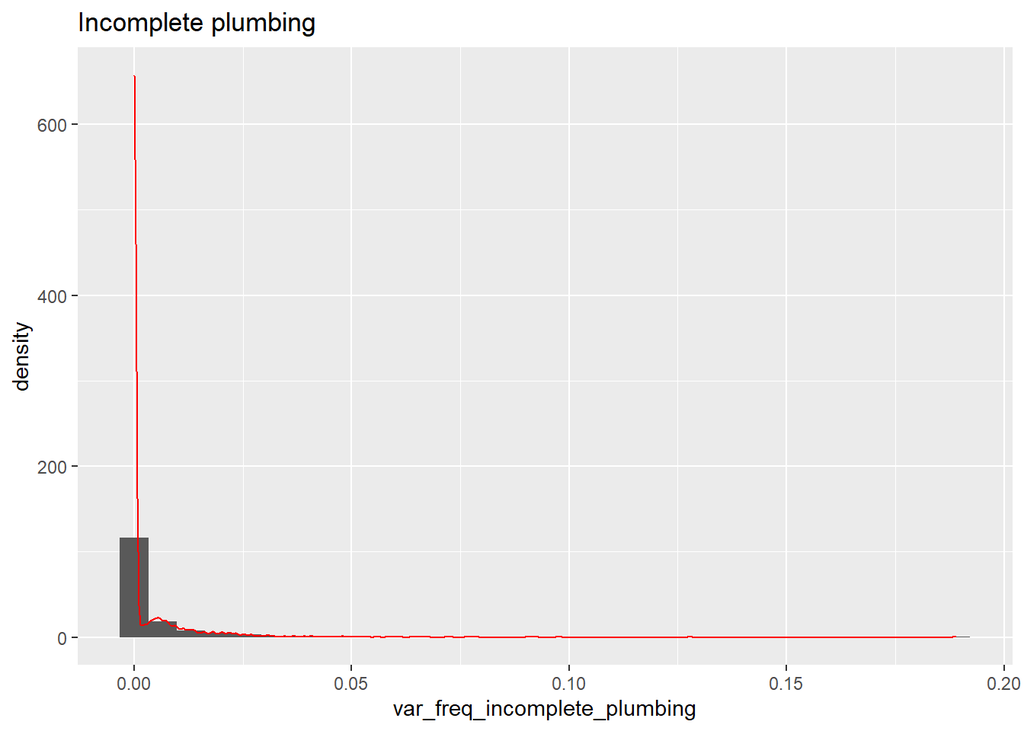

```r
ggplot(data = data_acs_incomplete_plumbing, aes(var_freq_incomplete_plumbing)) +
  geom_histogram(aes(y = after_stat(density))) +
  geom_density(color = "red") +
  ggtitle("Incomplete plumbing")
```

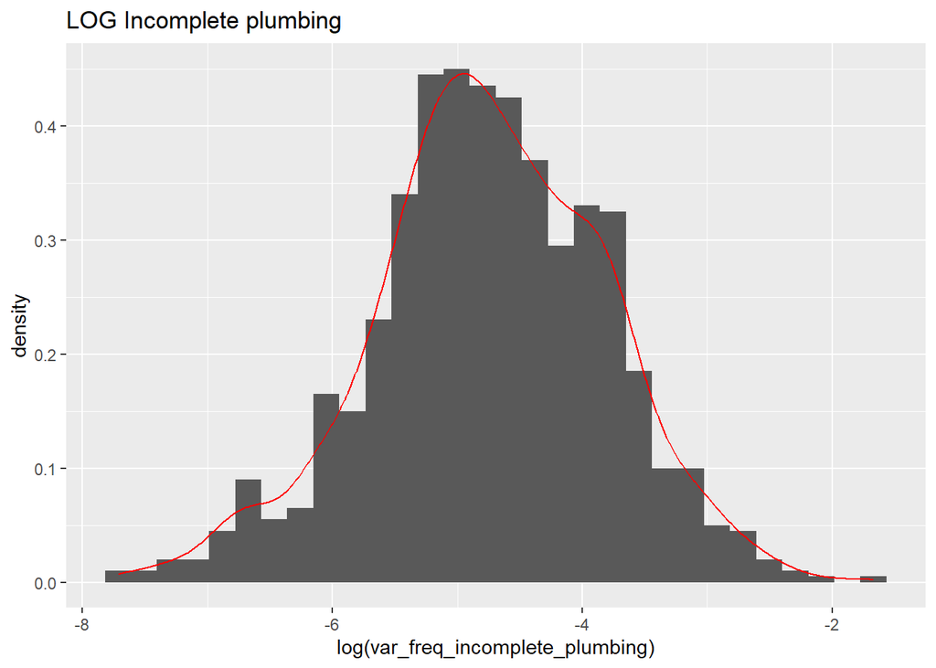

```r
ggplot(data = data_acs_incomplete_plumbing, aes(log(var_freq_incomplete_plumbing))) +
  geom_histogram(aes(y = after_stat(density))) +
  geom_density(color = "red") +
  ggtitle("LOG Incomplete plumbing")
```

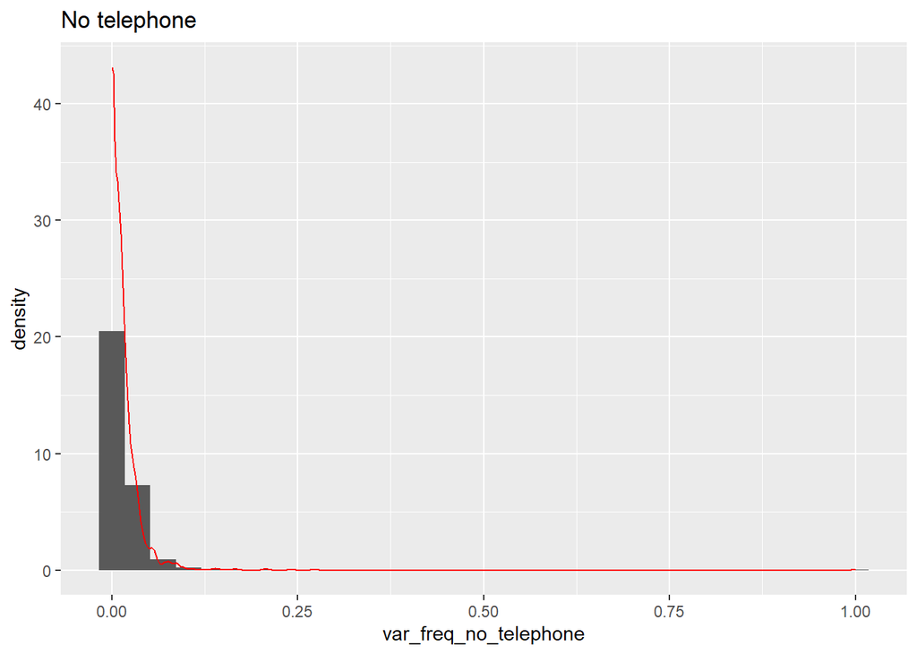

```r
ggplot(data = data_acs_no_telephone, aes(var_freq_no_telephone)) +
  geom_histogram(aes(y = after_stat(density))) +
  geom_density(color = "red") +
  ggtitle("No telephone")
```

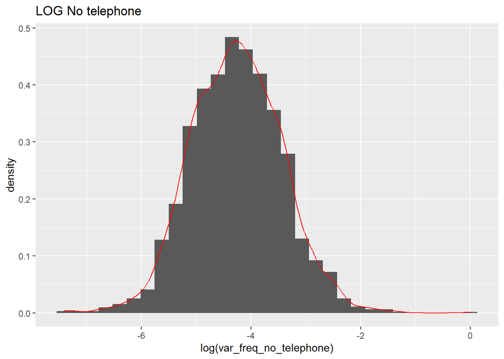

```r
ggplot(data = data_acs_no_telephone, aes(log(var_freq_no_telephone))) +
  geom_histogram(aes(y = after_stat(density))) +
  geom_density(color = "red") +
  ggtitle("LOG No telephone")
```

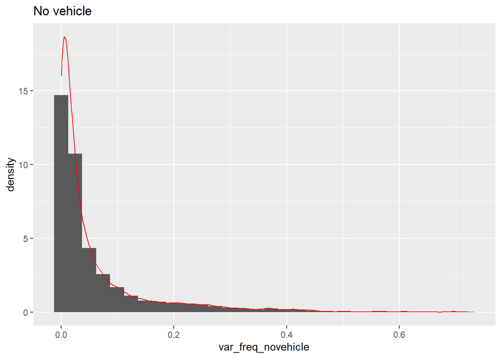

```r
ggplot(data = data_acs_novehicle, aes(var_freq_novehicle)) +
  geom_histogram(aes(y = after_stat(density))) +
  geom_density(color = "red") +
  ggtitle("No vehicle")
```

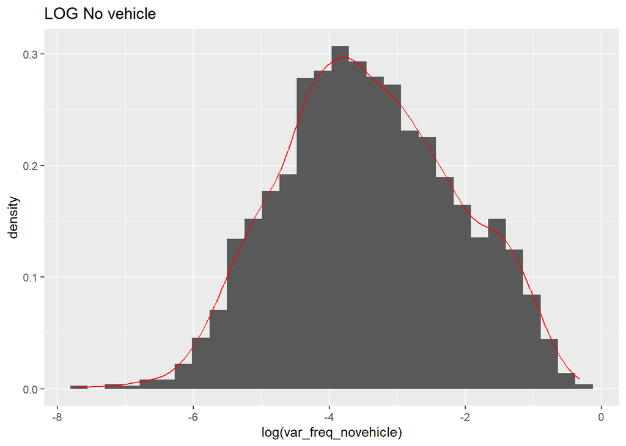

```r
ggplot(data = data_acs_novehicle, aes(log(var_freq_novehicle))) +
  geom_histogram(aes(y = after_stat(density))) +
  geom_density(color = "red") +
  ggtitle("LOG No vehicle")
```

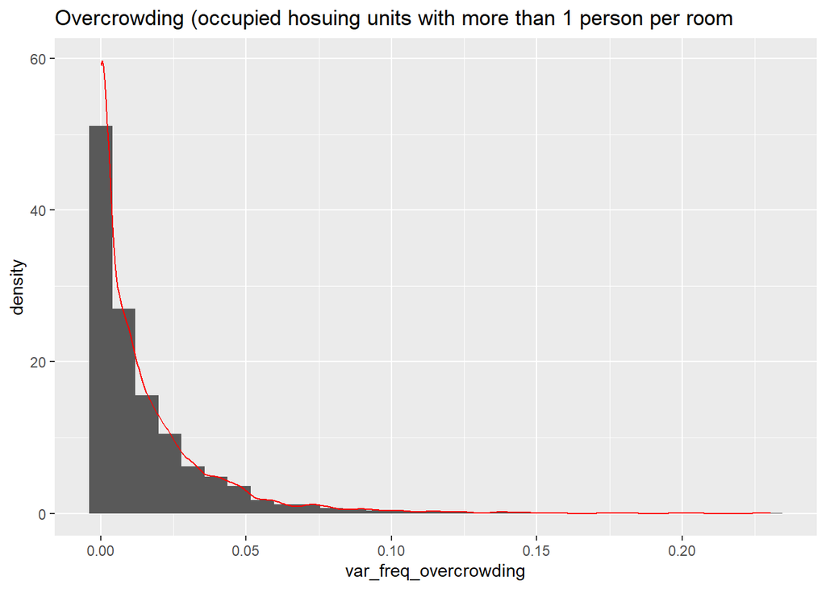

```r
ggplot(data = data_acs_overcrowding, aes(var_freq_overcrowding)) +
  geom_histogram(aes(y = after_stat(density))) +
  geom_density(color = "red") +
  ggtitle("Overcrowding (occupied hosuing units with more than 1 person per room")
```

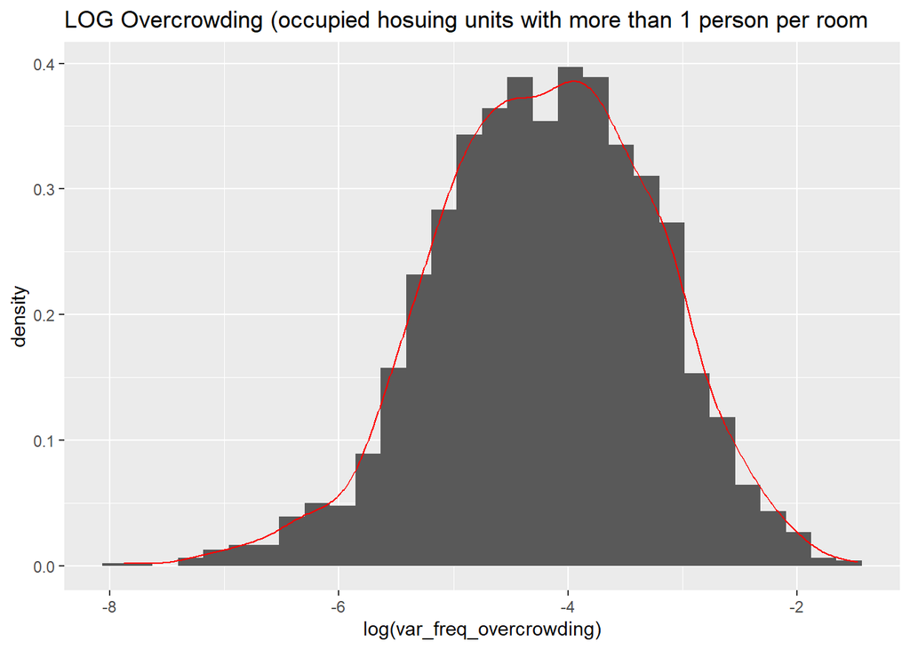

```r
ggplot(data = data_acs_overcrowding, aes(log(var_freq_overcrowding))) +
  geom_histogram(aes(y = after_stat(density))) +
  geom_density(color = "red") +
  ggtitle("LOG Overcrowding (occupied hosuing units with more than 1 person per room")
```

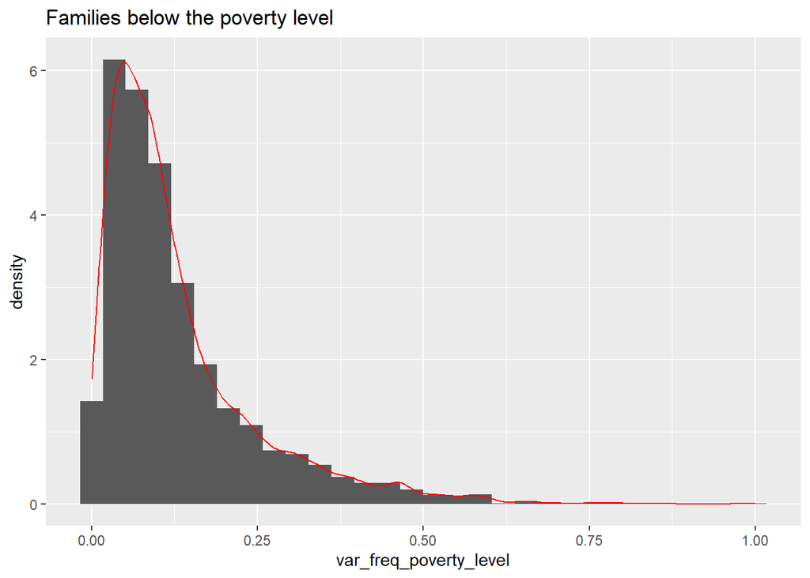

```r
ggplot(data = data_acs_poverty_level, aes(var_freq_poverty_level)) +
  geom_histogram(aes(y = after_stat(density))) +
  geom_density(color = "red") +
  ggtitle("Families below the poverty level")
```

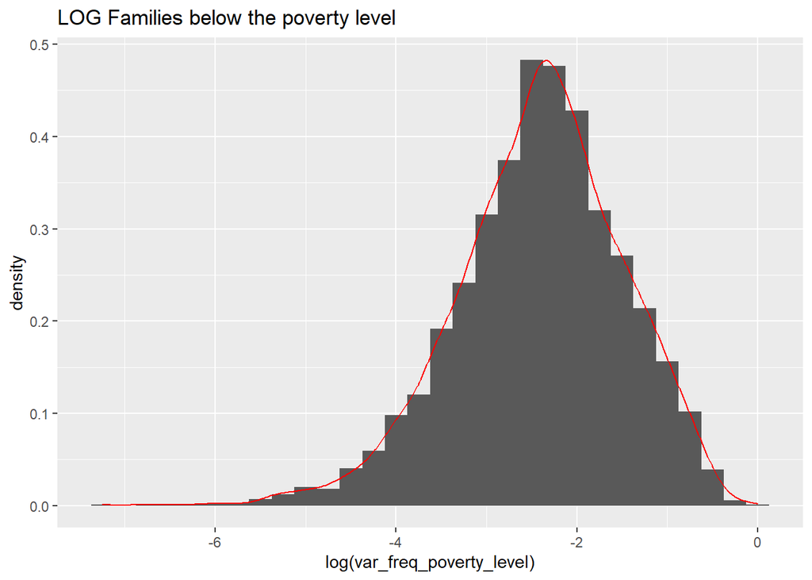

```r
ggplot(data = data_acs_poverty_level, aes(log(var_freq_poverty_level))) +
  geom_histogram(aes(y = after_stat(density))) +
  geom_density(color = "red") +
  ggtitle("LOG Families below the poverty level")
```

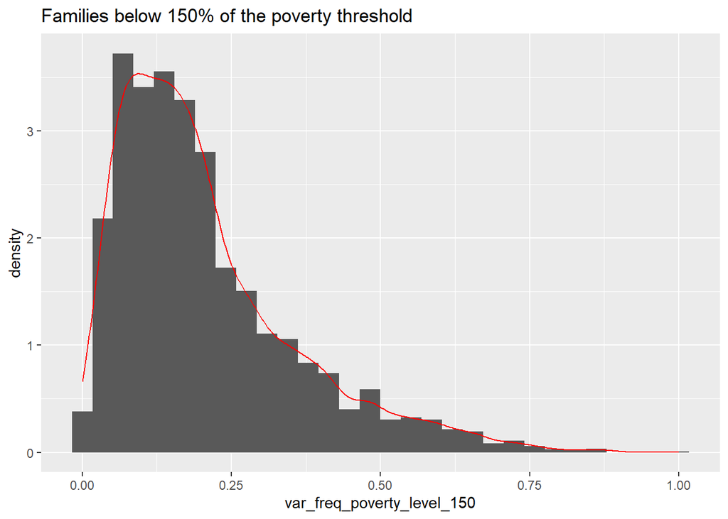

```r
ggplot(data = data_acs_poverty_level_150, aes(var_freq_poverty_level_150)) +
  geom_histogram(aes(y = after_stat(density))) +
  geom_density(color = "red") +
  ggtitle("Families below 150% of the poverty threshold")
```

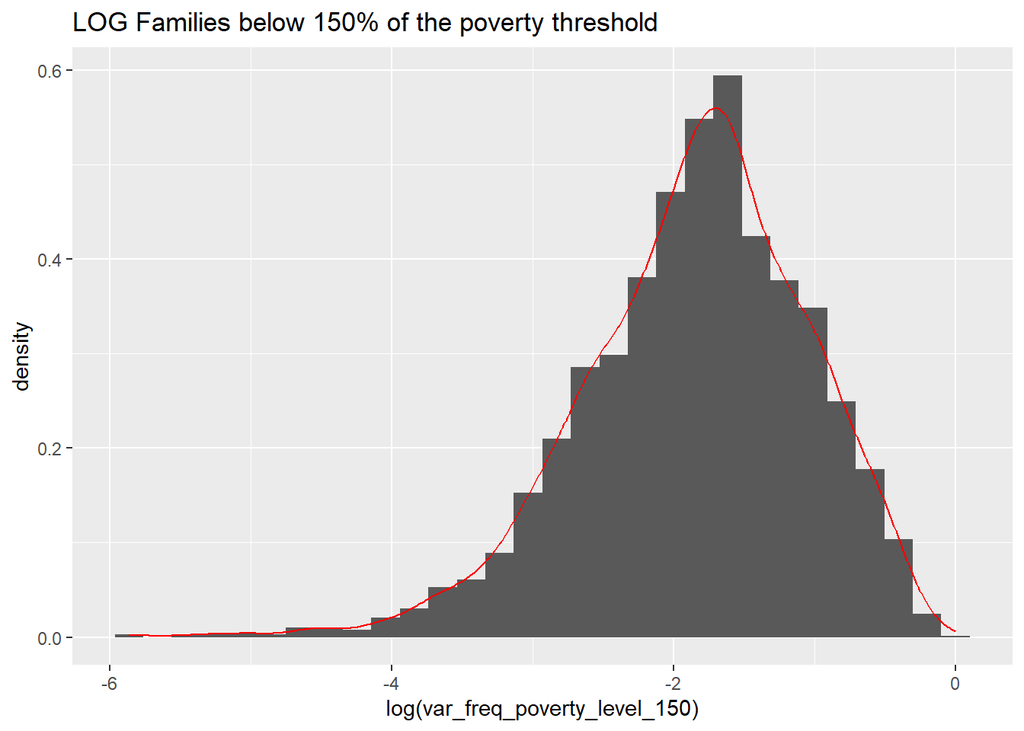

```r
ggplot(data = data_acs_poverty_level_150, aes(log(var_freq_poverty_level_150))) +
  geom_histogram(aes(y = after_stat(density))) +
  geom_density(color = "red") +
  ggtitle("LOG Families below 150% of the poverty threshold")
```

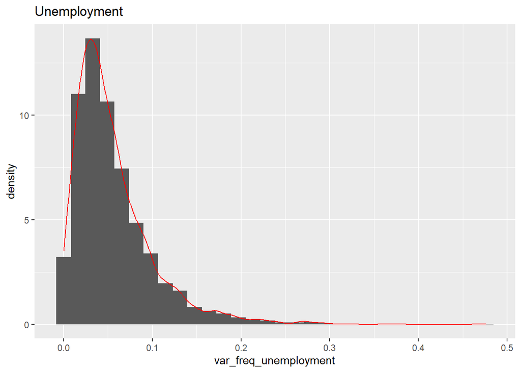

```r
ggplot(data = data_acs_unemployment, aes(var_freq_unemployment)) +
  geom_histogram(aes(y = after_stat(density))) +
  geom_density(color = "red") +
  ggtitle("Unemployment")
```

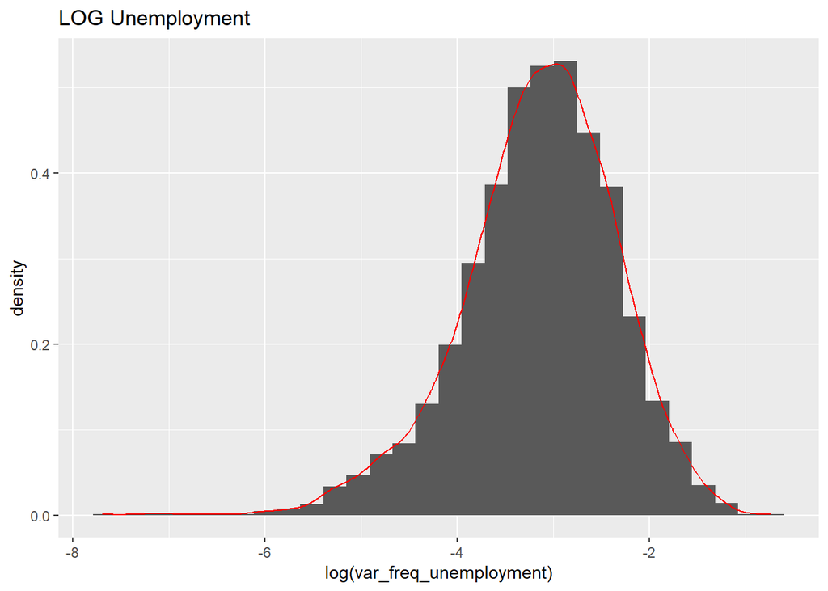

```r
ggplot(data = data_acs_unemployment, aes(log(var_freq_unemployment))) +
  geom_histogram(aes(y = after_stat(density))) +
  geom_density(color = "red") +
  ggtitle("LOG Unemployment")
```

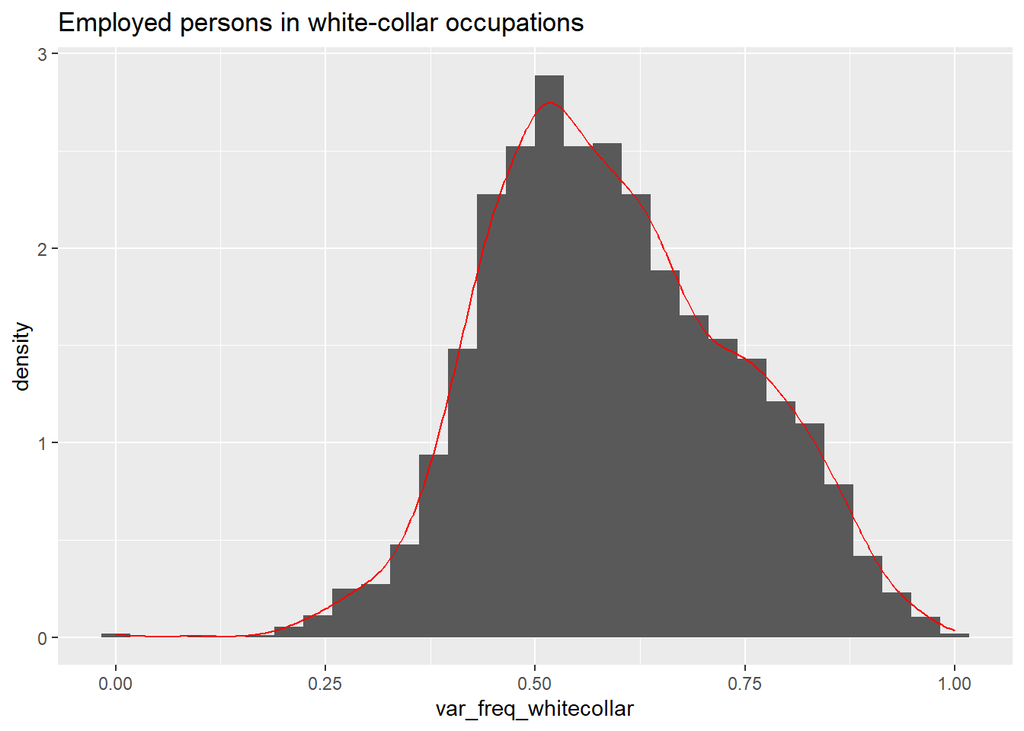

```r
ggplot(data = data_acs_whitecollar, aes(var_freq_whitecollar)) +
  geom_histogram(aes(y = after_stat(density))) +
  geom_density(color = "red") +
  ggtitle("Employed persons in white-collar occupations")
```

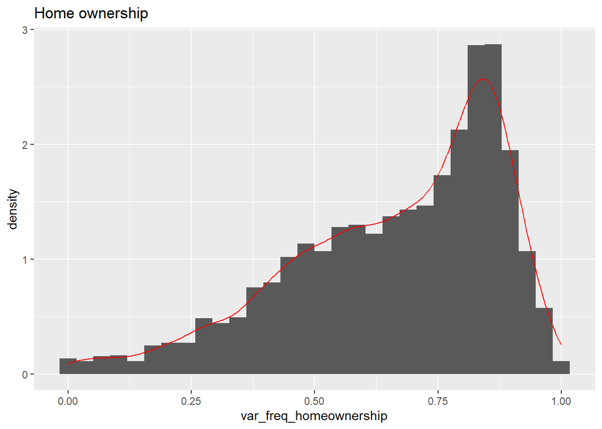

```r
ggplot(data = data_dhc_homeownership, aes(var_freq_homeownership)) +
  geom_histogram(aes(y = after_stat(density))) +
  geom_density(color = "red") +
  ggtitle("Home ownership")
```

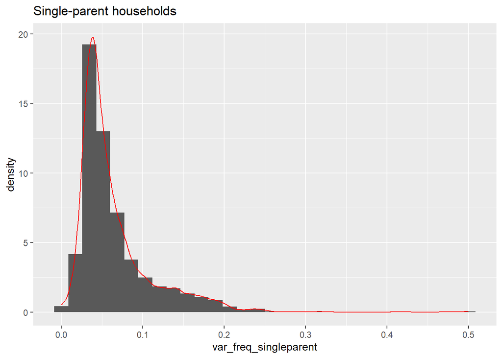

```r
ggplot(data = data_dhc_singleparent, aes(var_freq_singleparent)) +
  geom_histogram(aes(y = after_stat(density))) +
  geom_density(color = "red") +
  ggtitle("Single-parent households")
```

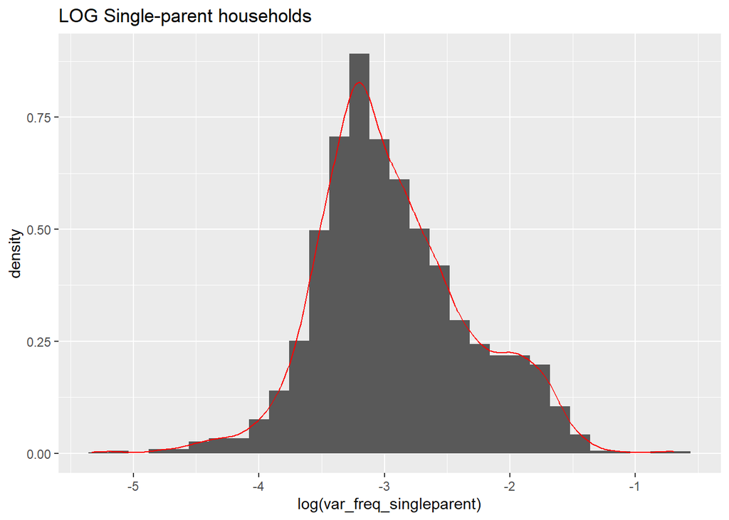

```r
ggplot(data = data_dhc_singleparent, aes(log(var_freq_singleparent))) +
  geom_histogram(aes(y = after_stat(density))) +
  geom_density(color = "red") +
  ggtitle("LOG Single-parent households")
```

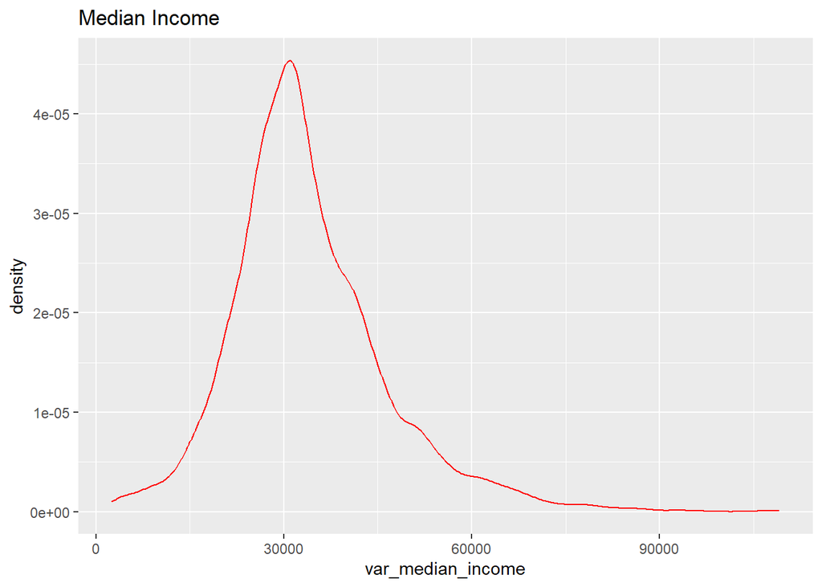

```r
ggplot(data = data_acs_median_income, aes(var_median_income)) +
  geom_histogram(aes(y = after_stat(density)), breaks = seq(0, 80, 1)) +
  geom_density(color = "red") +
  ggtitle("Median Income")
```

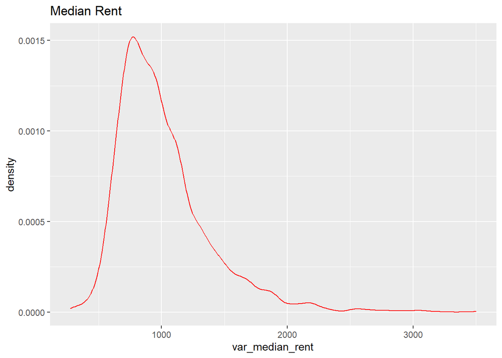

```r
ggplot(data = data_acs_median_rent, aes(var_median_rent)) +
  geom_histogram(aes(y = after_stat(density)), breaks = seq(0, 80, 1)) +
  geom_density(color = "red") +
  ggtitle("Median Rent")
```

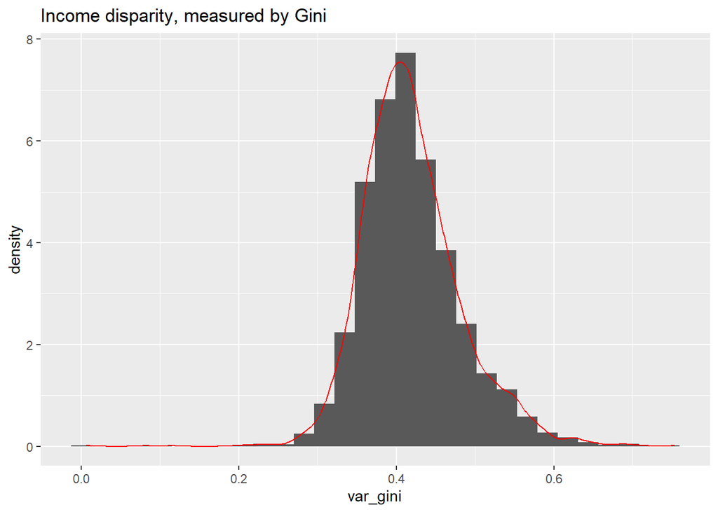

```r
ggplot(data = data_acs_gini, aes(var_gini)) +
  geom_histogram(aes(y = after_stat(density))) +
  geom_density(color = "red") +
  ggtitle("Income disparity, measured by Gini")
```

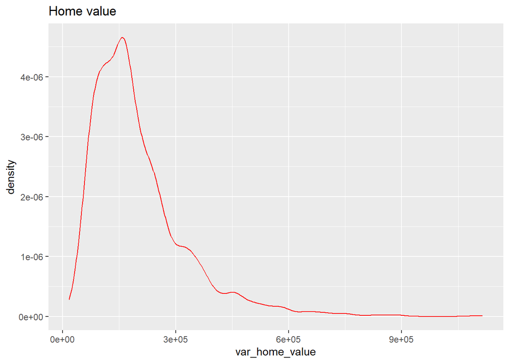

```r
ggplot(data = data_acs_home_value, aes(var_home_value)) +
  geom_histogram(aes(y = after_stat(density)), breaks = seq(0, 80, 1)) +
  geom_density(color = "red") +
  ggtitle("Home value")
```

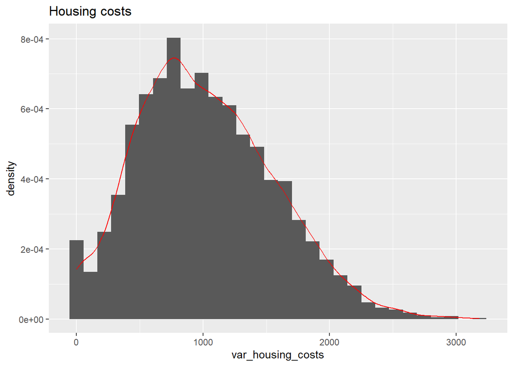

```r
ggplot(data = data_acs_housing_costs, aes(var_housing_costs)) +
  geom_histogram(aes(y = after_stat(density))) +
  geom_density(color = "red") +
  ggtitle("Housing costs")
```

Nine of the demographic variables benefited from log transformation. They are:

```
var_freq_lesshighschool
var_freq_incomplete_plumbing
var_freq_no_telephone
var_freq_novehicle
var_freq_overcrowding
var_freq_poverty_level
var_freq_poverty_level_150
var_freq_unemployment
var_freq_singleparent
```

We therefore update these nine variables with their log transformation.

For values of 0, we add a small constant (1e-5) before applying the log transformation. This avoids taking the log of zero, thus eliminating -Inf. We do this instead of replacing the values with “NA” because the zeroes are real, and we do not want to lose them from our dataset.

```r
# List of variables to log-transform
variables_to_log <- c(
  "var_freq_lesshighschool",
  "var_freq_incomplete_plumbing",
  "var_freq_no_telephone",
  "var_freq_novehicle",
  "var_freq_overcrowding",
  "var_freq_poverty_level",
  "var_freq_poverty_level_150",
  "var_freq_unemployment",
  "var_freq_singleparent"
)

# Apply log transformation and rename variables
merged_data <- merged_data |>
  mutate(across(
    all_of(variables_to_log),
    ~ log(. + 1e-5),
    .names = "{.col}_log"
  ))
```

### 3.3 Preparing the data: health outcomes

Import CDC PLACES data, which contains health outcomes data.

```r
# The data is taken from the following URL. Unfortunately the code to import the data is not working properly, so we downloaded it as a CSV file and here import the file.
# https://data.cdc.gov/download/PLACES-Local-Data-for-Better-Health-Census-Tract-D/excel/PLACES-Local-Data-for-Better-Health-Census-Tract-D.xlsx

data_places = read_csv("PLACES__Local_Data_for_Better_Health__Census_Tract_Data_2024_release_20241027.csv")
# rename variable "LocationName" to "GEOID" to be consistent with census data
data_places <- data_places |>
    rename("GEOID" = "LocationName")

# Filter to include only Pennsylvania
data_places=data_places |> filter(StateAbbr=="PA")
```

Create a dataset of several important health outcomes. Of note, mortality data is not included, as it is not available via PLACES, and special permission is required for access. The health outcomes data are expressed as frequencies.

```r
# Filter to include only the obesity data
data_places_obesity=data_places |> filter(Measure=="Obesity among adults") |> select(GEOID, Data_Value) |> rename(Rate_Obesity = Data_Value)

# Filter to include stroke data
data_places_stroke=data_places |> filter(Measure=="Stroke among adults") |> select(GEOID, Data_Value) |> rename(Rate_Stroke = Data_Value)

# Filter to include coronary heart disease data
data_places_heart=data_places |> filter(Measure=="Coronary heart disease among adults") |> select(GEOID, Data_Value) |> rename(Rate_Heart = Data_Value)

# Filter to include disability data
data_places_disability=data_places |> filter(Measure=="Any disability among adults") |> select(GEOID, Data_Value) |> rename(Rate_Disability = Data_Value)

# Filter to include fair or poor self-rated health status
data_places_healthrating=data_places |> filter(Measure=="Fair or poor self-rated health status among adults") |> select(GEOID, Data_Value) |> rename(Rate_Healthrating = Data_Value)

merged_outcomes = data_places_obesity |>
  left_join(data_places_stroke, by = "GEOID") |>
  left_join(data_places_heart, by = "GEOID") |>
  left_join(data_places_disability, by = "GEOID") |>
  left_join(data_places_healthrating, by = "GEOID")
```

### 3.4 Preparing the data: merging the predictor and outcomes datasets

First we check how many tracts are included in our dataset with both demographic and health outcomes data.

```r
## We check if there are values in the demographic data that are not within the health outcomes data, or vice versa.
length(setdiff(merged_data$GEOID, merged_outcomes$GEOID)) #There are 38 rows in the demographic data that are not in the health outcomes data.
```

```
[1] 38
```

```r
# We check the data for the missing tracts. We sample a few of them.
setdiff(merged_data$GEOID, merged_outcomes$GEOID)
```

```
 [1] "42003980000" "42003980100" "42003980300" "42003980400" "42003980500"
 [6] "42003980600" "42003980700" "42003980800" "42003980900" "42003981000"
[11] "42003981100" "42003981200" "42017980000" "42045980000" "42045980200"
[16] "42049990000" "42091980000" "42091980200" "42091980300" "42101036901"
[21] "42101980001" "42101980002" "42101980003" "42101980100" "42101980300"
[26] "42101980400" "42101980500" "42101980600" "42101980701" "42101980702"
[31] "42101980800" "42101980901" "42101980902" "42101980903" "42101980904"
[36] "42101980905" "42101980906" "42101989200"
```

```r
merged_data |> filter(GEOID == 42101036901) #an example of one we checked
```

```
# A tibble: 1 × 27
  GEOID     var_freq_lesshighsch…¹ var_freq_associates_…² var_freq_incomplete_…³
  <chr>                      <dbl>                  <dbl>                  <dbl>
1 42101036…                    NaN                      0                     NA
# ℹ abbreviated names: ¹var_freq_lesshighschool, ²var_freq_associates_college,
#   ³var_freq_incomplete_plumbing
# ℹ 23 more variables: var_freq_no_telephone <dbl>, var_freq_novehicle <dbl>,
#   var_freq_overcrowding <dbl>, var_freq_poverty_level <dbl>,
#   var_freq_poverty_level_150 <dbl>, var_freq_unemployment <dbl>,
#   var_freq_whitecollar <dbl>, var_freq_homeownership <dbl>,
#   var_freq_singleparent <dbl>, var_median_income <dbl>, …
```

```r
# They seem to be empty aside from the GEOID in the demographic dataset. It seems that for whatever reason, this tract does not have any demographic data and it is okay to remove them from the analyses, and use only those with demographic and outcomes data.

# Number of tracts with demographic data
num_tracts_demographic <- merged_data |> distinct(GEOID) |> nrow()

# Number of tracts with health outcomes data
num_tracts_health_outcomes <- merged_outcomes |> distinct(GEOID) |> nrow()

# Number of tracts with both demographic and health outcomes data
num_tracts_both <- merged_outcomes |> inner_join(merged_data, by = "GEOID") |> distinct(GEOID) |> nrow()

# Create a summary table
summary_table <- data.frame(
  Category = c("# Tracts with Demographic Data", "# Tracts with Health Outcomes Data", "# Tracts with Both Demographic and Health Outcomes Data"),
  Number_of_Tracts = c(num_tracts_demographic, num_tracts_health_outcomes, num_tracts_both)
)

# Print the summary table
kable(summary_table, caption = "Summary of Tracts with Data", align = c("l", "r"), digits = 0)
```

Summary of Tracts with Data

| Category | Number_of_Tracts |
| --- | --- |
| # Tracts with Demographic Data | 3446 |
| # Tracts with Health Outcomes Data | 3408 |
| # Tracts with Both Demographic and Health Outcomes Data | 3408 |

Next we check our data missingness. Overall we have fairly low missingness in the sociodemographic characteristics, and no missingness in the health outcomes variables.

```r
# List of demographic variables
vars_demographic <- c(
  "var_freq_lesshighschool_log",
  "var_freq_associates_college",
  "var_freq_incomplete_plumbing_log",
  "var_freq_no_telephone_log",
  "var_freq_novehicle_log",
  "var_freq_overcrowding_log",
  "var_freq_poverty_level_log",
  "var_freq_poverty_level_150_log",
  "var_freq_unemployment_log",
  "var_freq_whitecollar",
  "var_freq_homeownership",
  "var_freq_singleparent_log",
  "var_median_income",
  "var_median_rent",
  "var_gini",
  "var_home_value",
  "var_housing_costs"
)

# Subset the dataframe to include only the columns you're interested in
merged_data_subset <- merged_data[, vars_demographic]

# Calculate the missingness for each variable
missingness_table_demographics <- data.frame(
  Variable = colnames(merged_data_subset),  # List of variables
  Missingness = sapply(colnames(merged_data_subset), function(var) {
    # Calculate the percentage of missing values for each variable
    mean(is.na(merged_data_subset[[var]]), na.rm = TRUE) * 100
  })
)

# Reset row names to avoid duplication issues in the final table
rownames(missingness_table_demographics) <- NULL

# Print the table using kable to make it more presentable
missingness_table_demographics |>
  kable(col.names = c("Variable", "Missing Data"),
        caption = "Missing Data for Demographic Variables (%)",
        align = c("l", "r"),
        format = "markdown")
```

Missing Data for Demographic Variables (%)

| Variable | Missing Data |
| --- | --- |
| var_freq_lesshighschool_log | 1.2768427 |
| var_freq_associates_college | 0.0000000 |
| var_freq_incomplete_plumbing_log | 1.3639002 |
| var_freq_no_telephone_log | 1.3639002 |
| var_freq_novehicle_log | 1.4509576 |
| var_freq_overcrowding_log | 1.3639002 |
| var_freq_poverty_level_log | 1.2478236 |
| var_freq_poverty_level_150_log | 1.2478236 |
| var_freq_unemployment_log | 1.2768427 |
| var_freq_whitecollar | 1.2478236 |
| var_freq_homeownership | 0.6674405 |
| var_freq_singleparent_log | 0.6674405 |
| var_median_income | 1.1897853 |
| var_median_rent | 4.8752176 |
| var_gini | 1.4799768 |
| var_home_value | 2.6407429 |
| var_housing_costs | 0.0000000 |

```r
# List of outcomes variables
vars_outcomes <- c(
  "Rate_Obesity",
  "Rate_Stroke",
  "Rate_Heart",
  "Rate_Disability",
  "Rate_Healthrating"
)

# Subset the dataframe to include only the columns you're interested in
merged_outcomes_subset <- merged_outcomes[, vars_outcomes]

# Calculate the missingness for each variable
missingness_table_outcomes <- data.frame(
  Variable = colnames(merged_outcomes_subset),  # List of variables
  Missingness = sapply(colnames(merged_outcomes_subset), function(var) {
    # Calculate the percentage of missing values for each variable
    mean(is.na(merged_outcomes_subset[[var]]), na.rm = TRUE) * 100
  })
)

# Reset row names to avoid duplication issues in kable
rownames(missingness_table_outcomes) <- NULL

# Print the table using kable to make it more presentable
missingness_table_outcomes |>
  kable(col.names = c("Variable", "Missing Data"),
        caption = "Missing Data for Health Outcomes Variables (%)",
        align = c("l", "r"),
        format = "markdown")
```

Missing Data for Health Outcomes Variables (%)

| Variable | Missing Data |
| --- | --- |
| Rate_Obesity | 0 |
| Rate_Stroke | 0 |
| Rate_Heart | 0 |
| Rate_Disability | 0 |
| Rate_Healthrating | 0 |

## 4 Results

### 4.1 Examination of the data: sociodemographic variables and health outcomes

First we observe basic summary statistics for the demographic variables of interest, as well as the five health outcomes we will be examining: obesity, stroke, coronary heart disease, disability, and self-rated health.

```r
# Create a summary table for the demographic variables
summary_table_demographics <- merged_data_subset |>
  summarise(across(everything(),
                   list(mean = ~mean(. , na.rm = TRUE),
                        sd = ~sd(. , na.rm = TRUE),
                        missing = ~sum(is.na(.))),
                   .names = "{.col}_{.fn}")) |>
  pivot_longer(cols = everything(),
               names_to = c("Characteristic", "Statistic"),
               names_pattern = "(.*)_(.*)") |>
  pivot_wider(names_from = Statistic, values_from = value) |>
  mutate(
    # Round mean and sd to 2 decimal places
    `Average (Standard Deviation), N=3446` = paste0(round(mean, 2), " (", round(sd, 2), ")"),
    Missingness = missing
  ) |>
  select(Characteristic, `Average (Standard Deviation), N=3446`, Missingness)

# View the summary table
summary_table_demographics
```

```
# A tibble: 17 × 3
   Characteristic                   Average (Standard Deviation), …¹ Missingness
   <chr>                            <chr>                                  <dbl>
 1 var_freq_lesshighschool_log      -2.83 (1.32)                              44
 2 var_freq_associates_college      0.56 (0.18)                                0
 3 var_freq_incomplete_plumbing_log -9.6 (3.08)                               47
 4 var_freq_no_telephone_log        -6.19 (3.28)                              47
 5 var_freq_novehicle_log           -4.79 (3.25)                              50
 6 var_freq_overcrowding_log        -6.81 (3.59)                              47
 7 var_freq_poverty_level_log       -2.46 (1.11)                              43
 8 var_freq_poverty_level_150_log   -1.88 (0.97)                              43
 9 var_freq_unemployment_log        -3.32 (1.41)                              44
10 var_freq_whitecollar             0.59 (0.15)                               43
11 var_freq_homeownership           0.66 (0.21)                               23
12 var_freq_singleparent_log        -2.97 (0.85)                              23
13 var_median_income                33903.41 (12398.48)                       41
14 var_median_rent                  1011.1 (370.1)                           168
15 var_gini                         0.42 (0.06)                               51
16 var_home_value                   199784.41 (125496.18)                     91
17 var_housing_costs                1022.13 (538.68)                           0
# ℹ abbreviated name: ¹`Average (Standard Deviation), N=3446`
```

```r
# Create a summary table for the outcomes variables
summary_table_outcomes <- merged_outcomes_subset |>
  summarise(across(everything(),
                   list(mean = ~mean(. , na.rm = TRUE),
                        sd = ~sd(. , na.rm = TRUE),
                        missing = ~sum(is.na(.))),
                   .names = "{.col}_{.fn}")) |>
  pivot_longer(cols = everything(),
               names_to = c("Characteristic", "Statistic"),
               names_pattern = "(.*)_(.*)") |>
  pivot_wider(names_from = Statistic, values_from = value) |>
  mutate(
    # Round mean and sd to 2 decimal places
    `Average (Standard Deviation), N=3446` = paste0(round(mean, 2), " (", round(sd, 2), ")"),
    Missingness = missing
  ) |>
  select(Characteristic, `Average (Standard Deviation), N=3446`, Missingness)

# View the summary table
summary_table_outcomes
```

```
# A tibble: 5 × 3
  Characteristic    `Average (Standard Deviation), N=3446` Missingness
  <chr>             <chr>                                        <dbl>
1 Rate_Obesity      34.31 (5.25)                                     0
2 Rate_Stroke       3.82 (1.19)                                      0
3 Rate_Heart        7.53 (1.83)                                      0
4 Rate_Disability   32.1 (6.76)                                      0
5 Rate_Healthrating 19.64 (6.58)                                     0
```

Next we examine the distributions of the health outcomes data, using both bar graphs and chloropleth maps to see the distributions across the state of Pennsylvania in 2020.

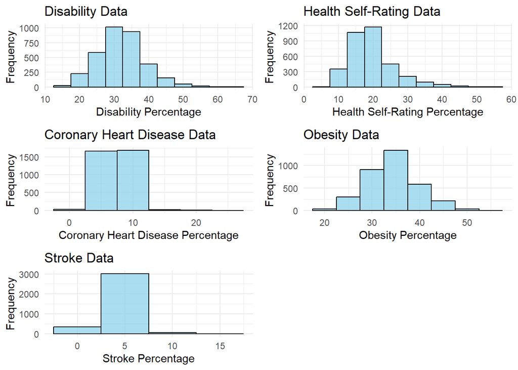

```r
# Disability
plot_disability = ggplot(merged_outcomes, aes(x = Rate_Disability)) +
  geom_histogram(binwidth = 5, fill = "skyblue", color = "black", alpha = 0.7) +
  labs(title = "Disability Data",
       x = "Disability Percentage",
       y = "Frequency") +
  theme_minimal()

# Health Self-Rating
plot_healthrating = ggplot(merged_outcomes, aes(x = Rate_Healthrating)) +
  geom_histogram(binwidth = 5, fill = "skyblue", color = "black", alpha = 0.7) +
  labs(title = "Health Self-Rating Data",
       x = "Health Self-Rating Percentage",
       y = "Frequency") +
  theme_minimal()

# Coronary Heart Disease
plot_heart = ggplot(merged_outcomes, aes(x = Rate_Heart)) +
  geom_histogram(binwidth = 5, fill = "skyblue", color = "black", alpha = 0.7) +
  labs(title = "Coronary Heart Disease Data",
       x = "Coronary Heart Disease Percentage",
       y = "Frequency") +
  theme_minimal()

# Obesity
plot_obesity = ggplot(merged_outcomes, aes(x = Rate_Obesity)) +
  geom_histogram(binwidth = 5, fill = "skyblue", color = "black", alpha = 0.7) +
  labs(title = "Obesity Data",
       x = "Obesity Percentage",
       y = "Frequency") +
  theme_minimal()

# Stroke
plot_stroke = ggplot(merged_outcomes, aes(x = Rate_Stroke)) +
  geom_histogram(binwidth = 5, fill = "skyblue", color = "black", alpha = 0.7) +
  labs(title = "Stroke Data",
       x = "Stroke Percentage",
       y = "Frequency") +
  theme_minimal()

# Combine the plots into one graphic
grid.arrange(plot_disability, plot_healthrating, plot_heart, plot_obesity, plot_stroke, ncol = 2)
```

Chloropleth maps:

```r
# We start by creating a base map of Pennsylvania.
pa.tracts = tracts(cb = TRUE, resolution = "500k",year="2020")
```

```
Retrieving Census tracts for the entire United States
```

```r
pa.tracts = pa.tracts |>  filter(STATEFP == 42)
```

Next we create chloropleth maps for each of the health outcomes variables. These maps help us visualize the distribution of the health outcomes data across Pennsylvania tracts. The white areas indicate missing data.

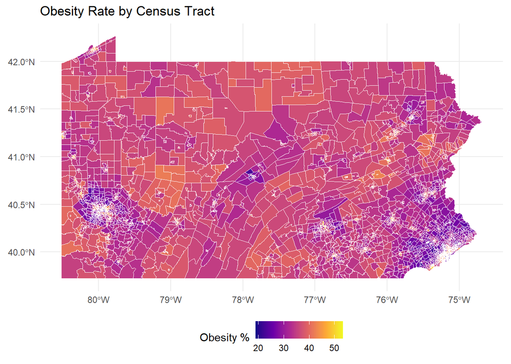

```r
merged_data_outcomes <- pa.tracts |>
  inner_join(merged_outcomes, by = c("GEOID" = "GEOID"))

# Obesity
ggplot(data = merged_data_outcomes) +
  geom_sf(aes(fill = Rate_Obesity), color = "white", size = 0.2) +
  scale_fill_viridis_c(option = "C") +  # You can change this to a different color scale
  labs(title = "Obesity Rate by Census Tract",
       fill = "Obesity %") +
  theme_minimal() +
  theme(legend.position = "bottom")
```

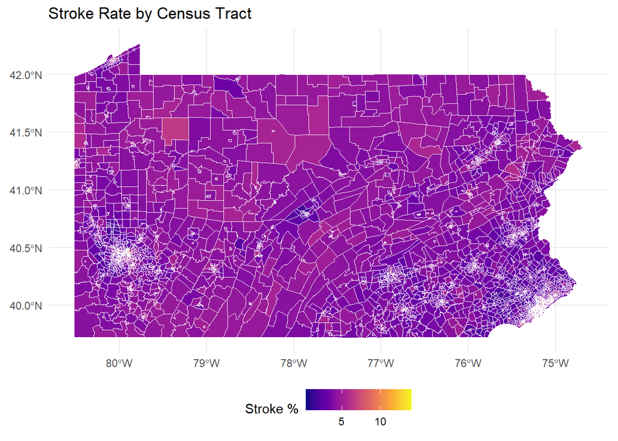

```r
# Stroke
ggplot(data = merged_data_outcomes) +
  geom_sf(aes(fill = Rate_Stroke), color = "white", size = 0.2) +
  scale_fill_viridis_c(option = "C") +
  labs(title = "Stroke Rate by Census Tract",
       fill = "Stroke %") +
  theme_minimal() +
  theme(legend.position = "bottom")
```

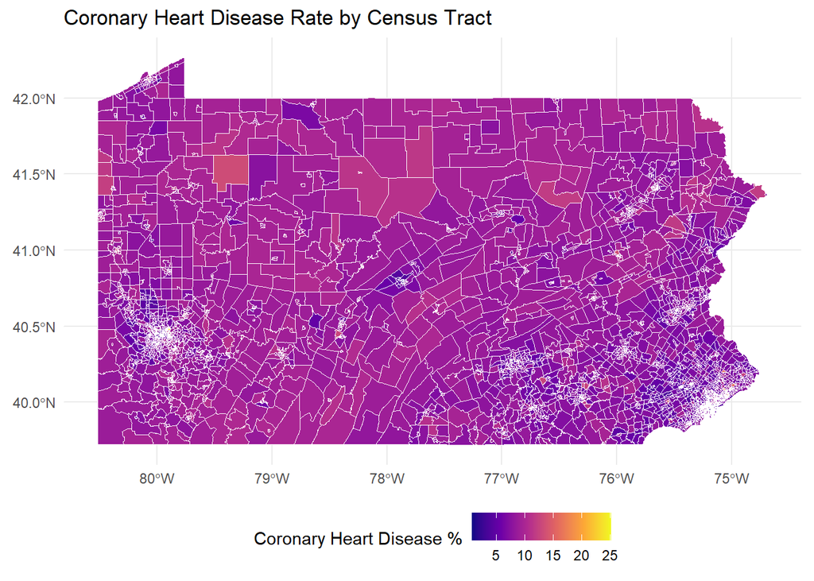

```r
# Coronary Heart Disease
ggplot(data = merged_data_outcomes) +
  geom_sf(aes(fill = Rate_Heart), color = "white", size = 0.2) +
  scale_fill_viridis_c(option = "C") +
  labs(title = "Coronary Heart Disease Rate by Census Tract",
       fill = "Coronary Heart Disease %") +
  theme_minimal() +
  theme(legend.position = "bottom")
```

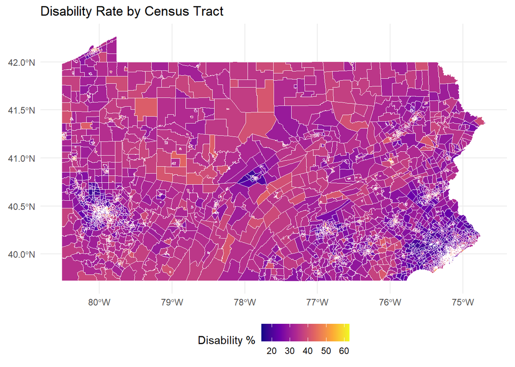

```r
# Disability
ggplot(data = merged_data_outcomes) +
  geom_sf(aes(fill = Rate_Disability), color = "white", size = 0.2) +
  scale_fill_viridis_c(option = "C") +
  labs(title = "Disability Rate by Census Tract",
       fill = "Disability %") +
  theme_minimal() +
  theme(legend.position = "bottom")
```

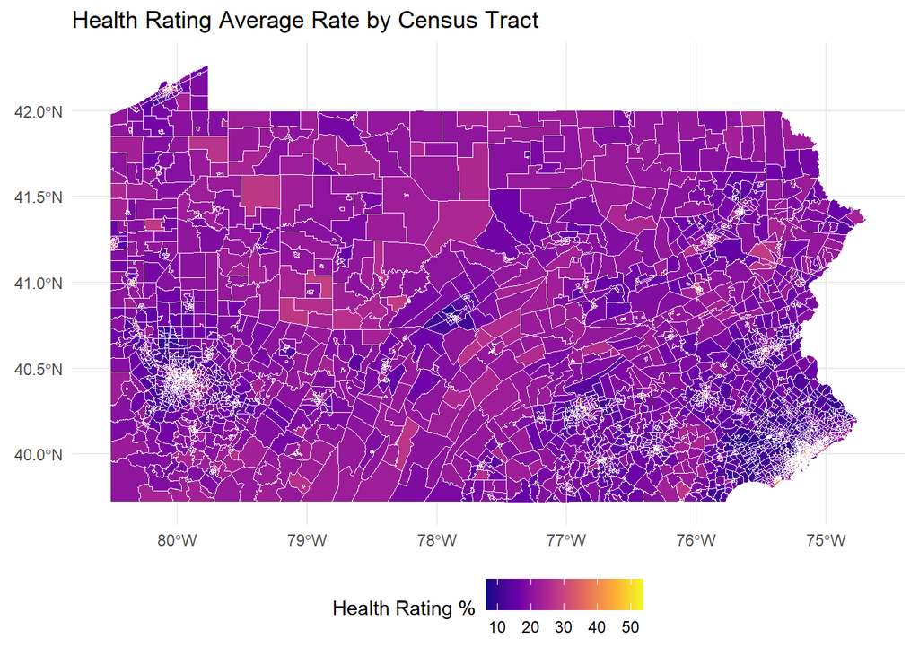

```r
# Self-rated health
ggplot(data = merged_data_outcomes) +
  geom_sf(aes(fill = Rate_Healthrating), color = "white", size = 0.2) +
  scale_fill_viridis_c(option = "C") +
  labs(title = "Health Rating Average Rate by Census Tract",
       fill = "Health Rating %") +
  theme_minimal() +
  theme(legend.position = "bottom")
```